# Incident analysis based on MITRE standards

Humbert Costas

11/06/2021

# Introducción

Como miembro del equipo de cybersecurity y experto en data science, se solicita tu colaboración para el análisis de un conjunto de incidentes de seguridad añadiendo información de contexto, que pueda ayudar a entender que sucedió y como mejorar.

## Objetivo

El objetivo consiste en responder las siguientes preguntas:

1. ¿Qué estandar/es podría/n añadir contexto a los incidentes?
2. ¿Cuantos incidentes estan relacionados con phishing?
3. ¿Quien estaba detras de los ataques?
4. ¿Cual fue el objetivo?
5. ¿Cómo realizaron los ataques?
6. ¿Cómo podemos protegernos?
7. ¿Qué podemos hacer para prevenir futuros ataques?
8. ¿Sería posible predecir ataques?

## Alcance

En total se pueden llegar a conseguir un máximo de 10 puntos.

Es posible hacer la práctica por parejas; en tal caso, los puntos totales se dividen entre los dos alumnos, consiguiendo un máximo de 8 puntos.

# Data sets

```r
suppressPackageStartupMessages(library("dplyr"))
library("tidyr")
suppressPackageStartupMessages(library("DataExplorer"))
library("ggridges")
library("ggplot2")
suppressPackageStartupMessages(library("hrbrthemes"))
suppressPackageStartupMessages(library("viridis"))
```

## Incidents

Load incidents data set and unnest ATT&CK column.

```r
raw_incidents <- readRDS(file = "data/incidents.rds")
incidents <- raw_incidents %>% unnest(mitre_attack)
summary(incidents)
```

```
##  first_event_ts                first_alert_ts
##  Min.   :2019-01-09 13:06:03   Min.   :2019-01-09 13:06:03
##  1st Qu.:2019-05-02 14:55:04   1st Qu.:2019-05-02 14:55:04
##  Median :2019-06-03 12:27:03   Median :2019-06-03 12:28:01
##  Mean   :2019-06-11 06:34:29   Mean   :2019-06-11 07:13:06
##  3rd Qu.:2019-07-16 12:22:05   3rd Qu.:2019-07-16 12:24:02
##  Max.   :2019-09-30 20:44:00   Max.   :2019-09-30 20:44:01
##  containment_ts                    org               tactic
##  Min.   :2019-04-01 12:19:24   Length:1941        Length:1941
##  1st Qu.:2019-05-06 16:38:17   Class :character   Class :character
##  Median :2019-06-03 13:38:11   Mode  :character   Mode  :character
##  Mean   :2019-06-13 02:54:36
##  3rd Qu.:2019-07-20 21:00:50
##  Max.   :2019-09-30 21:13:48
##   technique              id              industry
##  Length:1941        Length:1941        Length:1941
##  Class :character   Class :character   Class :character
##  Mode  :character   Mode  :character   Mode  :character
##
##
##
```

Analyze character columns to identify unique values.

```r
apply(incidents, 2, function(x) length(unique(x)))
```

```
## first_event_ts first_alert_ts containment_ts            org         tactic
##            376            378            381            167              9
##      technique             id       industry
##             28             28             19
```

Set character columns as factor.

```r
incidents <- incidents %>%
  mutate_if(is.character, as.factor)
summary(incidents)
```

```
##  first_event_ts                first_alert_ts
##  Min.   :2019-01-09 13:06:03   Min.   :2019-01-09 13:06:03
##  1st Qu.:2019-05-02 14:55:04   1st Qu.:2019-05-02 14:55:04
##  Median :2019-06-03 12:27:03   Median :2019-06-03 12:28:01
##  Mean   :2019-06-11 06:34:29   Mean   :2019-06-11 07:13:06
##  3rd Qu.:2019-07-16 12:22:05   3rd Qu.:2019-07-16 12:24:02
##  Max.   :2019-09-30 20:44:00   Max.   :2019-09-30 20:44:01
##
##  containment_ts                      org                   tactic
##  Min.   :2019-04-01 12:19:24   8cea5e51: 181   Execution      :1078
##  1st Qu.:2019-05-06 16:38:17   7b18b611: 178   Initial Access : 402
##  Median :2019-06-03 13:38:11   09deb14b: 124   Impact         : 160
##  Mean   :2019-06-13 02:54:36   fb0ad6ea: 116   Defense Evasion: 157
##  3rd Qu.:2019-07-20 21:00:50   2ac86da3:  97   Persistence    :  69
##  Max.   :2019-09-30 21:13:48   10cc3cd8:  84   Collection     :  28
##                                (Other) :1161   (Other)        :  47
##                 technique         id               industry
##  Third-Party Software:490   T1072  :490   Retail       :289
##  Valid Accounts      :309   T1078  :309   Professional :272
##  PowerShell          :268   T1086  :268   Manufacturing:237
##  Resource Hijacking  :160   T1496  :160   Construction :203
##  User Execution      :136   T1204  :136   Information  :147
##  Scripting           :121   T1064  :121   Educational  :146
##  (Other)             :457   (Other):457   (Other)      :647
```

```
## 6 features with more than 20 categories ignored!
## first_event_ts: 376 categories
## first_alert_ts: 378 categories
## containment_ts: 381 categories
## org: 167 categories
## technique: 28 categories
## id: 28 categories
```

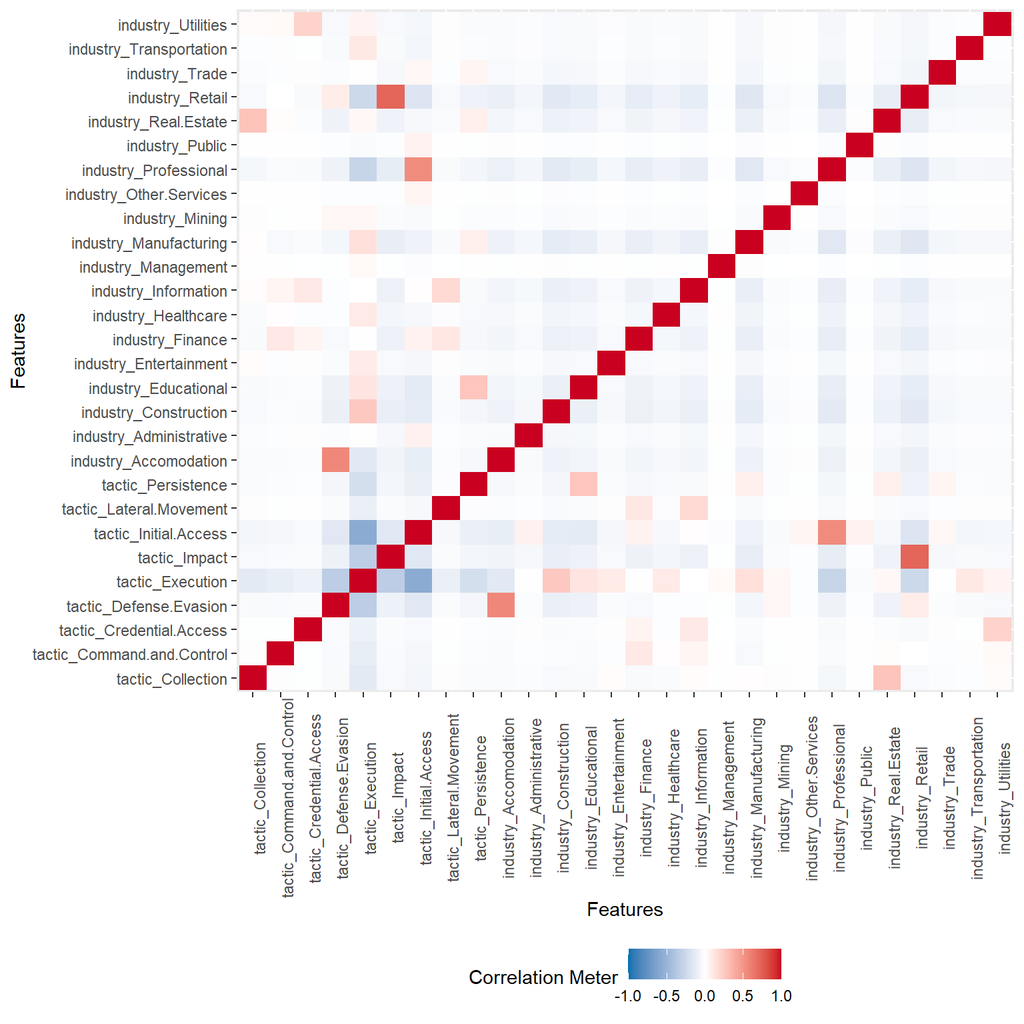

```r
plot_correlation(incidents)
```

Seems that Tactic and Industry values are interesting. Let’s see industry distribution along time.

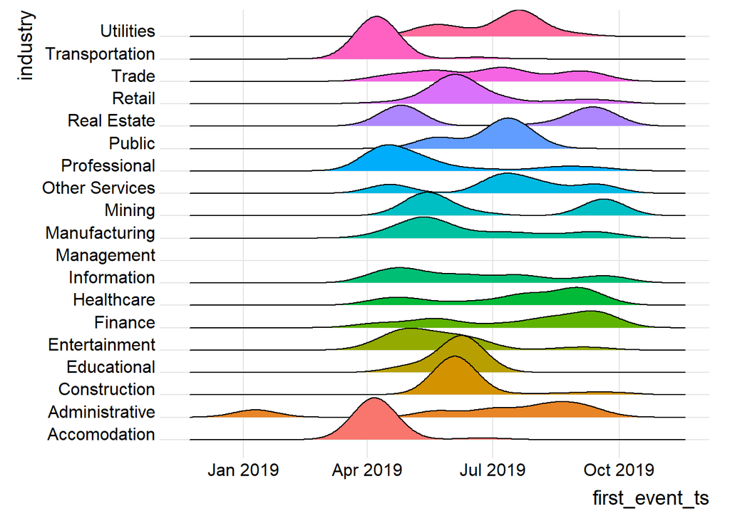

```r
# Ref: https://www.r-graph-gallery.com/294-basic-ridgeline-plot.html

ggplot(incidents, aes(x = first_event_ts, y = industry, fill = industry)) +
  geom_density_ridges() +
  theme_ridges() +
  theme(legend.position = "none")
```

The time series distribution is based on first event. We can calculate the duration of the incidents using containment time.

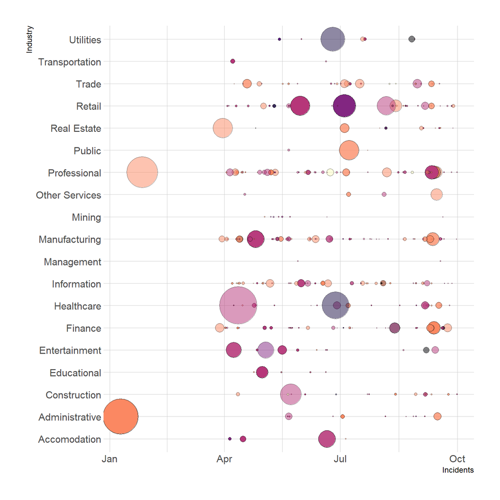

```r
# Ref: https://www.r-graph-gallery.com/320-the-basis-of-bubble-plot.html
incidents <- incidents %>% mutate(duration = round(as.numeric(containment_ts - first_event_ts)/3600, 2))

incidents %>%
  arrange(desc(first_event_ts)) %>%
  # mutate(country = factor(country, country)) %>%
  ggplot(aes(x=first_event_ts, y=industry, size=duration, fill=tactic)) +
  geom_point(alpha=0.5, shape=21, color="black") +
  scale_size(range = c(.1, 20), name="Duration") +
    scale_fill_viridis(discrete=TRUE, guide=FALSE, option="A") +
    theme_ipsum() +
    theme(legend.position="bottom") +
    ylab("Industry") +
    xlab("Incidents") +
    theme(legend.position = "none")
```

## CWE

```r
source("data-raw/mitre-cwe.R")
raw_cwes <- bind_rows(cwe.weaknesses, cwe.categories, cwe.views)
rm(cwe.weaknesses, cwe.categories, cwe.views)
dim(raw_cwes)
```

```
## [1] 1338   24
```

## CVE

```r
# source("data-raw/nist-cve.R")
# raw_cves <- ""
```

## ATT&CK

```r
# source("data-raw/mitre-attck.R")
```

## SHIELD

```r
# source("data-raw/mitre-shield.R")
```

## CPE

```r
# source("data-raw/nist-cpe.R")
```

## CAPEC

```r
# source("data-raw/mitre-capec.R")
```

## CAR

```r
# source("data-raw/mitre-car.R")
```

# Data Model

[figure not shown]

CyberSecurity Standards

# Análisis

## ¿Qué estandar/es podría/n añadir contexto a los incidentes?

## ¿Cuantos incidentes estan relacionados con phishing?

## ¿Quien estaba detras de los ataques?

## ¿Cómo realizaron los ataques?

## ¿Cómo podemos protegernos?

## ¿Qué podemos hacer para prevenir futuros ataques?

## ¿Sería posible predecir ataques?